# Info for Hydrostatic-Equation Test

The hydrostatic equation relates the change in pressure to the temperature and change in geometric altitude, so with low uncertainty in altitude (from the GPS measurements) the consistency between pressure and temperature can be tested. In this section, it is assumed that the temperature ATX is correct and the pressure is calculated during the initial climb and compared to the measured pressure. In another application, the reverse assumption will be made, that the pressure is reliable so the temperature can be determined from a similar integration.

The integration is limited to the initial climb to altitude, perhaps including brief pauses in the climb rate. Some compensation is applied to the measurements of temperature to adjust for the time delay, which is assumed to be characterized by a 2.3 s time constant. The two dashed red lines on either side of the blue line represent changes that would arise from a constant 0.5 deg. C offset in temperature. It is common for there to be a significant offset in measurements near the surface. This may be caused by a transient response of the temperature sensor when it first encounters significant dynamic heating, or it may also result from horizontal inhomogeneity in the temperature structure over the airport and its immediate surroundings.

Representative plots for cases where this test works well are shown below. Usually, the predicted pressure from the hydrostatic equation (PSH) should remain within a few hPa of PSXC except for a low-altitude region at the start of the climb. Significant departures may be indications of problems in either PSXC or ATX.

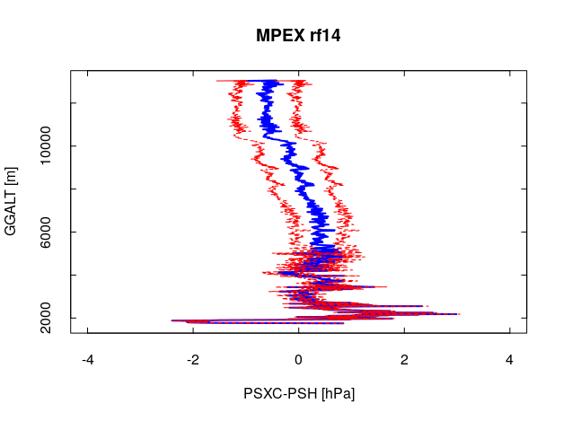

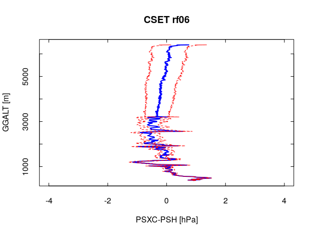